# Homework #4: Multiple Linear & Binary logistic Regression (Car Insurance)

#### Model Performance

The lasso model using coefficients extracted at `lambda.min` was used to predict the 536 test cases and compare the predicted insurance `TARGET_AMT` to the actual cost of a car crash.

```
## # A tibble: 5 x 3
##   .metric .estimator .estimate
##   <chr>   <chr>          <dbl>
## 1 mape    standard     165.
## 2 smape   standard      58.0
## 3 mase    standard       0.696
## 4 mpe     standard    -148.
## 5 rmse    standard    6614.
```

By analyzing graphs of our predictions and errors, we discovered a shortcoming of the lasso model - it failed to predict any costs less than $1,000.

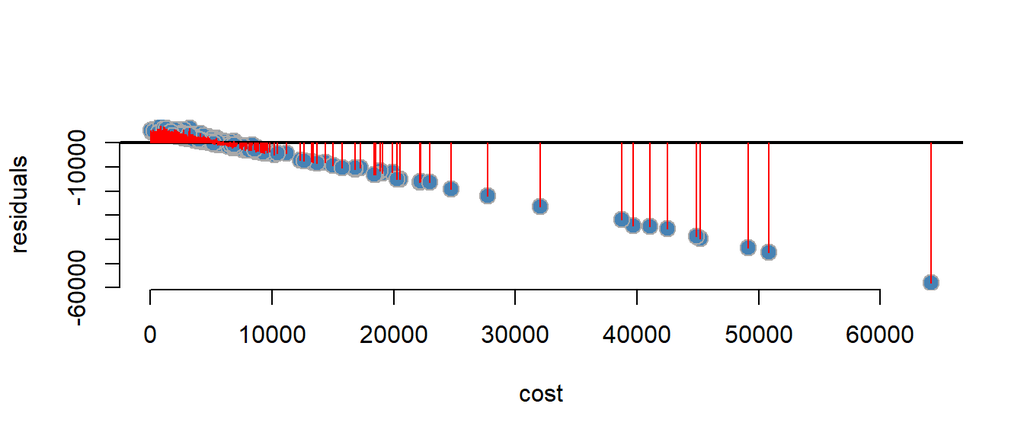

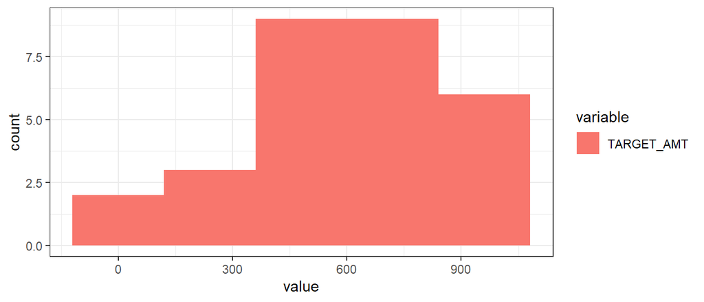

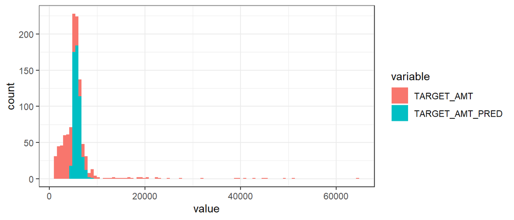

#### Model Assumptions

The Lasso method reduced multi-collinearity, keeping all the features but reducing the magnitude of the coefficients. This is often a good solution when many predictors contribute some information to the model.

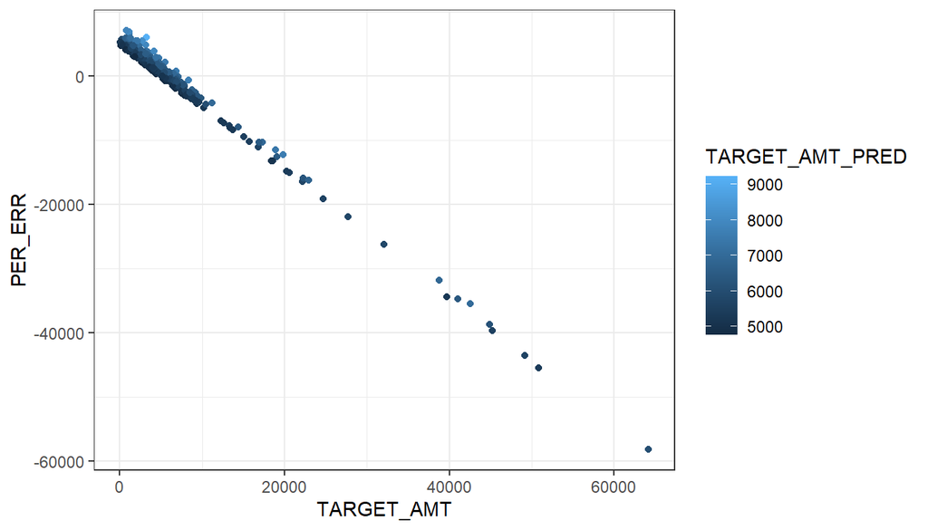

### 4.4 Linear Model Selection

During the exploratory data analysis, some predictor variables displayed signs of multi-collinearity, potentially causing unstable regression fits.

Results suggest that the model performance improved after applying transformations and methods for selecting significant predictor variables, such as Lasso and Variable Inflation Factor.

- Models 1 and 3 did not meet the assumption requirements for normal distributions and constant variance. Both had high RMSE.
- Model 2 more closely aligned with assumption requirements and performed best for MAPE and Accuracy.
- F-statistics for Models 1 and 2 were small, with significant p-values.
- AIC was lower for Model 2 than Model 1, while Model 3 produced unusual, negative results.
- Model 3 failed to predict costs of less than $1000.

Overall, Model 2 appeared to produce the best fit.

Linear Model Comparison

| Model | mape | smape | mase | mpe | RMSE | AIC | Adjusted R2 | F-statistic |
| --- | --- | --- | --- | --- | --- | --- | --- | --- |
| Model 1: Original data | 163.897 | 58.815 | 0.711 | -145.121 | 6621.310 | 3.366049e+04 | 0.020 | 9.184 |
| Model 2: Transforms + Stepwise | 7.299 | 7.085 | 0.681 | -1.150 | 0.821 | 3.883506e+03 | 0.019 | 4.854 |
| Model 3: Lasso | 165.092 | 57.972 | 0.696 | -148.312 | 6613.987 | -1.584024e+09 | NA | NA |

## 5. Predictions

#### Crash Predictions

Using Binary Logistic Regression Model 3 (Transformation + Lasso), we predicted TARGET_FLAG values for the 2141 observations in our evaluation dataset. We applied all training data transformations to the evaluation data as well. The prediction function generated a vector of probabilities between 0 and 1 that we used to calculate a binomial prediction applying a threshold of 0.5.

#### Cost Predictions

Using Multiple Linear Regression Model 2 (Transformation + Stepwise), we predicted `TARGET_AMT` values for the 352 observations in our evaluation dataset with a TARGET_FLAG of 1.

We applied all training data transformations to the evaluation data as well. The prediction function generated a vector of values representing the natural log of their “real world” values - we conducted a final transformation by exponentiation.

We wrote the results to a file “eval_predictions.csv” and saved it to the [GitHub repo](https://github.com/cliftonleesps/data621_group1/tree/main/hw4).

| TARGET_FLAG_PRED | TARGET_AMT_PRED | TARGET_FLAG_PROB | KIDSDRIV | AGE | HOMEKIDS | YOJ | INCOME | EDUCATION | JOB | TRAVTIME | BLUEBOOK | CAR_TYPE | OLDCLAIM | CLM_FREQ | MVR_PTS | MALE | MARRIED | LIC_REVOKED | CAR_RED | PRIVATE_USE | SINGLE_PARENT | URBAN | CAR_AGE_BIN | HOME_VAL_BIN | TIF_BIN |
| --- | --- | --- | --- | --- | --- | --- | --- | --- | --- | --- | --- | --- | --- | --- | --- | --- | --- | --- | --- | --- | --- | --- | --- | --- | --- |
| 0 | 0 | 0.1382 | 0 | 48 | 0 | 11 | 10.875818295293 | Bachelors | Manager | 12.7444136455618 | 221.871207894748 | Van | 0 | 0 | 2 | 1 | 0 | 0 | 1 | 1 | 0 | 1 | 3 | 1 | 1 |
| 0 | 0 | 0.2618 | 1 | 40 | 1 | 11 | 10.8359665446068 | High School | Manager | 10.7598933756684 | 206.893061958902 | Minivan | 8.10046489102936 | 1 | 2 | 1 | 0 | 0 | 0 | 1 | 1 | 1 | 1 | 1 | 3 |
| 0 | 0 | 0.1178 | 0 | 44 | 1 | 12 | 10.6802173218373 | High School | Blue Collar | 14.2520101672229 | 119.463743097547 | SUV | 0 | 0 | 0 | 0 | 0 | 0 | 0 | 0 | 1 | 0 | 3 | 1 | 4 |
| 0 | 0 | 0.2661 | 0 | 35 | 1 | 10 | 9.96199228190869 | High School | Clerical | 28.2487878172854 | 147.572823725929 | Pickup | 0 | 0 | 0 | 1 | 0 | 1 | 0 | 1 | 1 | 0 | 2 | 1 | 3 |
| 0 | 0 | 0.1548 | 0 | 59 | 0 | 12 | 11.3789482586999 | High School | Manager | 19.4534484530131 | 187.892612895393 | Minivan | 10.7112572239328 | 2 | 4 | 1 | 0 | 0 | 1 | 1 | 0 | 1 | 1 | 1 | 1 |
| 0 | 0 | 0.1804 | 0 | 46 | 0 | 14 | 11.5089877222276 | Bachelors | Professional | 4.18433727690475 | 238.629194328121 | Panel Truck | 7.65917136766606 | 1 | 2 | 1 | 1 | 0 | 0 | 0 | 0 | 1 | 3 | 3 | 1 |
| 0 | 0 | 0.4093 | 0 | 60 | 0 | 12 | 10.5437876005481 | High School | Blue Collar | 8.63037153676188 | 162.265036446041 | Sports Car | 0 | 0 | 0 | 0 | 1 | 0 | 0 | 0 | 0 | 1 | 1 | 3 | 1 |
| 0 | 0 | 0.3972 | 0 | 54 | 0 | 12 | 10.4106966445276 | &lt;High School | Blue Collar | 13.1273259772216 | 231.261895756199 | Panel Truck | 0 | 0 | 5 | 1 | 1 | 0 | 0 | 0 | 0 | 1 | 1 | 2 | 2 |
| 0 | 0 | 0.026 | 1 | 36 | 1 | 12 | 11.7794426326471 | Bachelors | Blue Collar | 2.99896265867799 | 245.238957281024 | Minivan | 0 | 0 | 0 | 0 | 0 | 0 | 0 | 0 | 1 | 0 | 3 | 4 | 2 |
| 0 | 0 | 0.1411 | 0 | 50 | 0 | 8 | 12.0285595097285 | PhD | Doctor | 11.1669966291415 | 272.827965781542 | Sports Car | 0 | 0 | 3 | 0 | 0 | 0 | 0 | 1 | 0 | 1 | 1 | 1 | 2 |

[output cut: 2131 more lines]

## 6. Conclusion

Overall, our approach of subsetting the problem into two separate models appeared to be effective. We used a Binary Logistic Regression to model the probability of crashes, and a Multiple Linear Regression to model the associated costs when a car crash occurred.

In both cases, we took steps to transform the data and reduce multi-collinearity for optimal results. For the Logistic model, Lasso Regression enabled us to keep most of the variables in the model but scale their coefficients according to their relative importance. For the Linear model, we used Stepwise feature selection based on AIC to arrive at a minimal feature set, reducing overall error, and producing reasonable outputs.

#### **Crash Factors**

The most important predictive factor of car crashes - by far - was living in a high-density Urban environment. Other factors included driving a Sports Car or SUV, having a high number of License Revocations, or having children in the household that drive.

On the other hand, factors that contributed to a lower probability of car crashes included having a Managerial job or being a Doctor, driving a car for Private (non-commercial) uses only, and being Married.

#### **Cost Factors**

The most important predictors for higher repair costs included having a high number of MVR points (moving violations), and a high Bluebook valuation of the vehicle. Factors that contributed to a lower predicted cost included a high number of prior Claims, and education levels of Bachelor’s or High School.

#### Further Questions

While many of these factors made intuitive sense, some caught our attention as candidates for further research and analysis. For example, do drivers with a high number of Claims tend to drive less expensive vehicles, or do they simply tend to get into lots of minor fender-benders instead of major accidents? Similarly, what is the relationship between Single Parents and higher crash likelihoods - even if it is not a strong relationship from a statistical significance standpoint?

For future consideration, we might also wish to look at the imbalanced class distribution between “crash” and “non-crash” events in the training data, where “non-crash” occurs about 75% of the time. Although we could not explore this further, imbalances like this can introduce additional bias to Logistic Regression models and might be addressed through re-sampling or ‘bootstrapping’ training data.

## 7. References

1. Faraway, J. J. (2014). *Linear Models with R, Second Edition.* CRC Press.
2. Sheather, S. (2009). *A Modern Approach to Regression with R.* Springer Science & Business Media.
3. *Detecting Multicollinearity Using Variance Inflation Factors* | STAT 462. (n.d.). https://online.stat.psu.edu/stat462/node/180/
4. James, Gareth, Daniela Witten, Trevor Hastie, and Robert Tibshirani. 2014. *An Introduction to Statistical Learning: With Applications in R.* Springer Publishing Company, Incorporated
5. Faraway, J. J. (2016). *Extending the Linear Model with R: Generalized Linear, Mixed Effects and Nonparametric Regression Models.* CRC Press.

## Appendix: R code

```r
## ----setup, include=FALSE-------------------------------------------------------------------------------------------------------------------------------------
# chunks
knitr::opts_chunk$set(echo=FALSE, eval=TRUE, include=TRUE,
message=FALSE, warning=FALSE, fig.align='center', fig.height=5)

# libraries
library(yardstick)
library(tidyverse)
library(janitor)
library(mice)
library(readr)
library(skimr)
library(ggplot2)
library(tidyverse)
library(reshape2)
library(MASS)
library(forecast)
library(kableExtra)
library(ggpubr)
library(fastDummies)
library(jtools)
library(performance)
library(broom)
library(pROC)

library(ggmosaic)
library(patchwork)

library(caTools)
library(corrplot)
library(Hmisc)
library(glmnet)
library(vip)
library(caret)

library(psych)
library(GGally)
library(campfin)

library(summarytools)
library(sjPlot)
library(olsrr)
library(car)

## To load the below libraries you might have to do the following in the console first:
####  install.packages("devtools")
####  install.packages("see")
####  devtools::install_github("haleyjeppson/ggmosaic")
####  devtools::install_github("thomasp85/patchwork")

# ggplot
theme_set(theme_bw())


## ----common functions-----------------------------------------------------------------------------------------------------------------------------------------
#' nice_table
#'
#' @param df
#' @param fw
nice_table <- function(df, cap=NULL, cols=NULL, dig=3, fw=F){
  if (is.null(cols)) {c <- colnames(df)} else {c <- cols}
  table <- df %>%
    kable(caption=cap, col.names=c, digits=dig) %>%
    kable_styling(
      bootstrap_options = c("striped", "hover", "condensed"),
      html_font = 'monospace',
      full_width = fw)
  return(table)
}

#' glmnet_cv_aicc
#'
#' @param fit
#' @param lambda
#'
#' @return
#' @export
#'
#' @examples
glmnet_cv_aicc <- function(fit, lambda = 'lambda.min'){
  whlm <- which(fit$lambda == fit[[lambda]])
  with(fit$glmnet.fit,
       {
         tLL <- nulldev - nulldev * (1 - dev.ratio)[whlm]
         k <- df[whlm]
         n <- nobs
         return(list('AICc' = - tLL + 2 * k + 2 * k * (k + 1) / (n - k - 1),
                     'BIC' = log(n) * k - tLL))
       })
}

#' coeff2dt
#'
#' @param fitobject
#' @param s
#'
#' @return
#' @export
#'
#' @examples
coeff2dt <- function(fitobject, s) {
  coeffs <- coef(fitobject, s)
  coeffs.dt <- data.frame(name = coeffs@Dimnames[[1]][coeffs@i + 1], coefficient = coeffs@x)

  # reorder the variables in term of coefficients
  return(coeffs.dt[order(coeffs.dt$coefficient, decreasing = T),])
}


## # only required for final knit

## h4, h5, .h4, .h5 {margin-top: 20px !important;}


## ----data-----------------------------------------------------------------------------------------------------------------------------------------------------
# read train and evaluation datasets
train_df <- read.csv("https://raw.githubusercontent.com/cliftonleesps/data621_group1/main/hw4/insurance_training_data.csv")
eval_df <- read.csv("https://raw.githubusercontent.com/cliftonleesps/data621_group1/main/hw4/insurance-evaluation-data.csv")


## ----summary1-------------------------------------------------------------------------------------------------------------------------------------------------
DT::datatable(
      train_df[1:25,],
      extensions = c('Scroller'),
      options = list(scrollY = 350,
                     scrollX = 500,
                     deferRender = TRUE,
                     scroller = TRUE,
                     dom = 'lBfrtip',
                     fixedColumns = TRUE,
                     searching = FALSE),
      rownames = FALSE)


## ----summary-traindf------------------------------------------------------------------------------------------------------------------------------------------
skim_without_charts(train_df) %>%
  dplyr::select(c(skim_variable, skim_type, n_missing, complete_rate,
                  numeric.p0, numeric.p100, numeric.mean)) %>%
  nice_table(cap='Summary: Training Dataset',cols=c('variable','type','missing',
                                    'complete%','min','max','mean'))


## ----summary-evaldf-------------------------------------------------------------------------------------------------------------------------------------------
skim_without_charts(eval_df) %>%
  dplyr::select(c(skim_variable, skim_type, n_missing, complete_rate,
                  numeric.p0, numeric.p100, numeric.mean)) %>%
  nice_table(cap='Summary: Evaluation Dataset',cols=c('variable','type','missing',
                                      'complete%','min','max','mean'))


## ----prep-----------------------------------------------------------------------------------------------------------------------------------------------------
# Drop INDEX
train_df <- train_df %>% dplyr::select(-INDEX)
 eval_df <- eval_df %>% dplyr::select(-c(INDEX, TARGET_FLAG, TARGET_AMT))

## Remove z_ from character class values
z_vars <- c("MSTATUS","SEX","JOB","CAR_TYPE","URBANICITY","EDUCATION")
for (v in z_vars) {
  train_df <- train_df %>% mutate(!!v := str_replace(get(v),"z_",""))
  eval_df <- eval_df %>% mutate(!!v := str_replace(get(v),"z_",""))
}

# Update RED_CAR, replace [no,yes] values with [No, Yes] values
train_df <- train_df %>% mutate( RED_CAR = ifelse(RED_CAR == "no","No","Yes"))
eval_df <- eval_df %>% mutate( RED_CAR = ifelse(RED_CAR == "no","No","Yes"))

# Instead of level "" will be "Unknown"
train_df$JOB[train_df$JOB==""] <- "Unknown"
eval_df$JOB[eval_df$JOB==""] <- "Unknown"

# Convert currency columns from character class to integer
dollar_vars <- c("INCOME","HOME_VAL","BLUEBOOK","OLDCLAIM")
for (v in dollar_vars) {
  train_df <- train_df %>% mutate(!!v := str_replace(get(v),"[\\$,]",""))
  eval_df <- eval_df %>% mutate(!!v := str_replace(get(v),"[\\$,]",""))
}

currency_vars <- c("INCOME","HOME_VAL","BLUEBOOK","OLDCLAIM")

for (v in currency_vars) {
  train_df <- train_df %>% mutate(!!v := parse_number(get(v)))
  eval_df <- eval_df %>% mutate(!!v := parse_number(get(v)))
}
```

```r
## -------------------------------------------------------------------------------------------------------------------------------------------------------------
dist_df <- train_df %>% dplyr::select(where(is.numeric)) %>%
  pivot_longer(!c(TARGET_FLAG,TARGET_AMT),
               names_to = 'variable',
               values_to = 'value') %>%
  drop_na()

dist_df %>% ggplot(aes(x=value, group=TARGET_FLAG, fill=TARGET_FLAG)) +
  geom_density(color='#023020') +
  facet_wrap(~variable, scales = 'free',  ncol = 4) +
  theme_bw()


## ----discrete_plot--------------------------------------------------------------------------------------------------------------------------------------------
train_df[,c("HOMEKIDS","KIDSDRIV", "CLM_FREQ")] %>%
  gather("variable","value") %>%
  group_by(variable) %>%
  count(value) %>%
  mutate(value = factor(value,levels=5:0)) %>%
  mutate(percent = n*100/8161) %>%
  ggplot(.,
  aes(variable,percent)) +
  geom_bar(stat = "identity", aes(fill = value)) +
  xlab("Variable") +
  ylab("Percentage") +
  theme(axis.text.x = element_text(angle = 90, hjust = 1)) +
  scale_fill_manual(values = rev(c("#003f5c","#58508d", "#bc5090", "#ff6361", "#ffa600","#CC79a7")))


## ----vars_to_factors------------------------------------------------------------------------------------------------------------------------------------------
factor_vars <- c("PARENT1","CAR_TYPE","JOB","CAR_USE",
                 "URBANICITY","RED_CAR","REVOKED","MSTATUS","EDUCATION","SEX")

for (v in factor_vars) {
  train_df <- train_df %>% mutate(!!v := factor(get(v)))
  eval_df <- eval_df %>% mutate(!!v := factor(get(v)))
}

train_df$TARGET_FLAG <- as.factor(train_df$TARGET_FLAG)


## -------------------------------------------------------------------------------------------------------------------------------------------------------------
train_df[,factor_vars] %>%
  gather("variable","value") %>%
  group_by(variable) %>%
  count(value) %>%
  mutate(value = factor(value)) %>%
  mutate(percent = n*100/8161) %>%
  ggplot(.,
  aes(variable,percent)) +
  geom_bar(stat = "identity", aes(fill = value)) +
  xlab("Variable") +
  ylab("Percent") +
  theme(axis.text.x = element_text(angle = 90, hjust = 1))


## ----boxplot--------------------------------------------------------------------------------------------------------------------------------------------------
dist_df %>% ggplot(aes(x=value, group=TARGET_FLAG, fill=TARGET_FLAG)) +
  geom_boxplot(color='#023020') +
  facet_wrap(~variable, scales = 'free',  ncol = 4) +
  theme_bw()


## ----scatterplot----------------------------------------------------------------------------------------------------------------------------------------------
dist_df %>% drop_na() %>% ggplot(aes(x=value, y=TARGET_AMT)) +
  geom_smooth(method='glm', se=TRUE, na.rm=TRUE) +
  geom_point(color='#023020', alpha=0.5) +
  facet_wrap(~variable, scales = 'free',  ncol = 4) +
  theme_bw()


## ----corr-----------------------------------------------------------------------------------------------------------------------------------------------------
rcore <- rcorr(as.matrix(train_df %>% dplyr::select(where(is.numeric))))
coeff <- rcore$r
corrplot(coeff, tl.cex = .5, tl.col="black", method = 'color', addCoef.col = "black",
         type="upper", order="hclust", number.cex=0.7, diag=FALSE)


## -------------------------------------------------------------------------------------------------------------------------------------------------------------
## Check JOB values where YOJ==0 and INCOME is NA
# train_df %>% filter(YOJ == 0 & is.na(INCOME)) %>% dplyr::select(JOB) %>% unique()

# Manual correction of missing/outlier values
train_df <- train_df %>%
  mutate(CAR_AGE = ifelse(CAR_AGE < 0, 0, CAR_AGE)) %>%
  mutate(INCOME = ifelse(YOJ == 0 & is.na(INCOME), 0, INCOME))

eval_df <- eval_df %>%
  mutate(INCOME = ifelse(YOJ == 0 & is.na(INCOME), 0, INCOME))


## ----impute---------------------------------------------------------------------------------------------------------------------------------------------------
# MICE imputation of missing values
imputed_Data <- mice(train_df, m=5, maxit = 20, method = 'pmm', seed = 500, printFlag=FALSE)
train_df <- complete(imputed_Data)

eval_imputed_Data <- mice(eval_df, m=5, maxit = 20, method = 'pmm', seed = 500, printFlag=FALSE)
eval_df <- complete(eval_imputed_Data)


## ----dummy_vars-----------------------------------------------------------------------------------------------------------------------------------------------
## Dummy Variables for factors with two levels
dummy_vars <- function(df){
  df %>%
    mutate(
      MALE = factor(ifelse(SEX == "M", 1, 0)),
      MARRIED = factor(ifelse(MSTATUS == "Yes", 1, 0)),
      LIC_REVOKED = factor(ifelse(REVOKED == "Yes", 1, 0)),
      CAR_RED = factor(ifelse(RED_CAR == "Yes", 1, 0)),
      PRIVATE_USE = factor(ifelse(CAR_USE == "Private", 1, 0)),
      SINGLE_PARENT = factor(ifelse(PARENT1 == "Yes", 1, 0)),
      URBAN = factor(ifelse(URBANICITY == "Highly Urban/ Urban", 1, 0)),
      KIDSDRIV = factor(ifelse(KIDSDRIV > 0, 1, 0)),
      HOMEKIDS = factor(ifelse(HOMEKIDS > 0, 1, 0))
    ) %>%
    dplyr::select(-c(SEX, MSTATUS, REVOKED, RED_CAR, CAR_USE, PARENT1, URBANICITY))
      }

train_df <- dummy_vars(train_df)
eval_df <- dummy_vars(eval_df)


## -------------------------------------------------------------------------------------------------------------------------------------------------------------
# keep original datasets for further lasso models, use transformed df for further transformations
train_transformed <- train_df
eval_transformed <- eval_df


## ----bin_vars-------------------------------------------------------------------------------------------------------------------------------------------------
## bin TIF, CAR_AGE, HOME_VAL
q <- quantile(train_transformed$CAR_AGE)
q <- c(-1,  1,  8, 12, 28)
train_transformed <- train_transformed %>%
  mutate(CAR_AGE_BIN = cut(CAR_AGE, breaks=q, labels=FALSE))
```

```r
q <- quantile(train_transformed$HOME_VAL)
q[1] <- -1
train_transformed <- train_transformed%>%
  mutate(HOME_VAL_BIN = cut(HOME_VAL, breaks=q, labels=FALSE))

q <- quantile(train_transformed$TIF)
q[1] <- -1
train_transformed <- train_transformed %>%
  mutate(TIF_BIN = cut(TIF, breaks=q, labels=FALSE))

q <- quantile(eval_transformed$CAR_AGE)
q <- c(-1,  1,  8, 12, 28)
eval_transformed <- eval_transformed %>%
  mutate(CAR_AGE_BIN = cut(CAR_AGE, breaks=q, labels=FALSE))

q <- quantile(eval_transformed$HOME_VAL)
q[1] <- -1
eval_transformed <- eval_transformed%>%
  mutate(HOME_VAL_BIN = cut(HOME_VAL, breaks=q, labels=FALSE))

q <- quantile(eval_transformed$TIF)
q[1] <- -1
eval_transformed <- eval_transformed %>%
  mutate(TIF_BIN = cut(TIF, breaks=q, labels=FALSE))


## ----boxcox, fig.keep="none"----------------------------------------------------------------------------------------------------------------------------------
# use Box-Cox on BLUEBOOK, TRAVTIME, TIF
bluebook_boxcox <- boxcox(lm(train_transformed$BLUEBOOK ~ 1))
bluebook_lambda <- bluebook_boxcox$x[which.max(bluebook_boxcox$y)]
bluebook_trans <- BoxCox(train_transformed$BLUEBOOK, bluebook_lambda)
train_transformed$BLUEBOOK <- bluebook_trans

bluebook_boxcox <- boxcox(lm(eval_transformed$BLUEBOOK ~ 1))
bluebook_lambda <- bluebook_boxcox$x[which.max(bluebook_boxcox$y)]
bluebook_trans <- BoxCox(eval_transformed$BLUEBOOK, bluebook_lambda)
eval_transformed$BLUEBOOK <- bluebook_trans

travtime_boxcox <- boxcox(lm(train_transformed$TRAVTIME ~ 1))
travtime_lambda <- travtime_boxcox$x[which.max(travtime_boxcox$y)]
travtime_trans <- BoxCox(train_transformed$TRAVTIME, travtime_lambda)
train_transformed$TRAVTIME <- travtime_trans

travtime_boxcox <- boxcox(lm(eval_transformed$TRAVTIME ~ 1))
travtime_lambda <- travtime_boxcox$x[which.max(travtime_boxcox$y)]
travtime_trans <- BoxCox(eval_transformed$TRAVTIME, travtime_lambda)
eval_transformed$TRAVTIME <- travtime_trans

tif_boxcox <- boxcox(lm(train_transformed$TIF ~ 1))
tif_lambda <- tif_boxcox$x[which.max(tif_boxcox$y)]
tif_trans <- BoxCox(train_transformed$TIF, tif_lambda)
train_transformed$TIF <- tif_trans

tif_boxcox <- boxcox(lm(eval_transformed$TIF ~ 1))
tif_lambda <- tif_boxcox$x[which.max(tif_boxcox$y)]
tif_trans <- BoxCox(eval_transformed$TIF, tif_lambda)
eval_transformed$TIF <- tif_trans

## Use basic log transformation on TARGET_AMT, OLDCLAIM
train_transformed <- train_transformed %>%
  mutate(TARGET_AMT = case_when(TARGET_FLAG==1 ~ log(TARGET_AMT) , TARGET_FLAG==0 ~ TARGET_AMT))
train_transformed$OLDCLAIM <- log(train_transformed$OLDCLAIM + 1)
train_transformed$INCOME <- log(train_transformed$INCOME + 1)

eval_transformed$OLDCLAIM <- log(eval_transformed$OLDCLAIM + 1)
eval_transformed$INCOME <- log(eval_transformed$INCOME + 1)


## -------------------------------------------------------------------------------------------------------------------------------------------------------------
skim_without_charts(train_transformed) %>%
  dplyr::select(c(skim_variable, skim_type, n_missing, complete_rate,
                  numeric.p0, numeric.p100, numeric.mean)) %>%
  nice_table(cap='Summary: Transformed Training Dataset',cols=c('variable','type','missing',
                                    'complete%','min','max','mean'))


## ----box_hists------------------------------------------------------------------------------------------------------------------------------------------------
## Create temporary CAR_CRASH variable from the target_flag for visualization
vis_df <- train_transformed %>%
  mutate(CAR_CRASH = ifelse(TARGET_FLAG == 1, 1, 0)) %>%
  dplyr::select(where(is.numeric)) %>%
  dplyr::select(!c(CAR_AGE_BIN, HOME_VAL_BIN, TIF_BIN)) %>% # exclude binned
  pivot_longer(!c(CAR_CRASH,TARGET_AMT),
               names_to = 'variable',
               values_to = 'value') %>%
  drop_na()

vis_df %>% ggplot(aes(x=value, group=CAR_CRASH, fill=CAR_CRASH)) +
  geom_density(color='#023020') +
  facet_wrap(~variable, scales = 'free',  ncol = 4) +
  theme_bw()


## ----split----------------------------------------------------------------------------------------------------------------------------------------------------
set.seed(1233)

# For Lasso Logistic model, original data without NAs, some vars to factors and opposite
log_original <- createDataPartition(train_df$TARGET_FLAG, p=0.75, list = FALSE)

train_data <- train_df[log_original, ] %>% dplyr::select(-c(TARGET_AMT))
valid_data <- train_df[-log_original, ] %>% dplyr::select(-c(TARGET_AMT))

# For other logistic models, transformed data, removed bin variables
log_transformed <- createDataPartition(train_transformed$TARGET_FLAG, p=0.75, list = FALSE)

log_train <- train_transformed[log_transformed,] %>%
  dplyr::select(-c(TARGET_AMT, TIF, CAR_AGE, HOME_VAL))

log_test <- train_transformed[-log_transformed,] %>%
  dplyr::select(-c(TARGET_AMT, TIF, CAR_AGE, HOME_VAL))

# For Lasso Linear model, original data without NAs, some vars to factors and opposite, only for TARGET_FLAG=1
original_yes_crash <- train_df %>%
  filter(TARGET_FLAG==1)

transformed_yes_crash <- train_transformed %>%
  filter(TARGET_FLAG==1)

linear_original <- createDataPartition(original_yes_crash$TARGET_AMT, p=0.75, list = FALSE)

linear_train_data <- original_yes_crash[linear_original, ] %>%
  dplyr::select(-c(TARGET_FLAG))

linear_valid_data <- original_yes_crash[-linear_original, ] %>%
  dplyr::select(-c(TARGET_FLAG))

# For other linear models, transformed data, removed bin variables
linear_transformed <- createDataPartition(transformed_yes_crash$TARGET_AMT, p=0.75, list = FALSE)

amt_train <- transformed_yes_crash[linear_transformed, ] %>%
  dplyr::select(-c(TARGET_FLAG, TIF, CAR_AGE, HOME_VAL))

amt_test <- transformed_yes_crash[-linear_transformed, ] %>%
  dplyr::select(-c(TARGET_FLAG, TIF, CAR_AGE, HOME_VAL))

eval_transformed <- eval_transformed %>%
  dplyr::select(-c(TIF, CAR_AGE, HOME_VAL))


## ----log_model1, warning=FALSE, message=FALSE-----------------------------------------------------------------------------------------------------------------
log_model_1 <- glm(train_data, formula = TARGET_FLAG ~ ., family = binomial(link = "logit"))
```

```r
## ----log_model1_aic, warning=FALSE, message=FALSE-------------------------------------------------------------------------------------------------------------
log_model_1_aic <- log_model_1 %>% stepAIC(trace = FALSE)
summ(log_model_1_aic)


## -------------------------------------------------------------------------------------------------------------------------------------------------------------
as.data.frame(summ(log_model_1_aic)$coeftable) %>%
  dplyr::select(Est.,p) %>%
  filter(p < 0.06 & Est. > 0.2) %>%
  arrange(desc(Est.)) %>%
  nice_table(cap='Positive Coefficients', cols=c('Est','p'))


## -------------------------------------------------------------------------------------------------------------------------------------------------------------
as.data.frame(summ(log_model_1_aic)$coeftable) %>%
  dplyr::select(Est.,p) %>%
  filter(p < 0.06 & Est. < -0.2) %>%
  arrange(Est.) %>%
  nice_table(cap='Negative Coefficients', cols=c('Est','p'))


## ----log_model_1_confusionMatrix, fig.height=4----------------------------------------------------------------------------------------------------------------
log_testing <- valid_data

log1_pred <- predict.glm(log_model_1_aic, log_testing, "response")

log_testing$prob_model_1 <- log1_pred
log_testing$pred_model_1 <- ifelse(log1_pred >= 0.5, 1, 0)

# Confusion Matrix
log_matrix_1 <- confusionMatrix(factor(log_testing$pred_model_1),
                                factor(log_testing$TARGET_FLAG), "1")

log_matrix_1

# Table
results_log <- tibble(
  Model = "Model #1: Original data",
  Accuracy=log_matrix_1$overall["Accuracy"],
  "Classification error rate" = 1 - log_matrix_1$overall["Accuracy"],
  F1 = log_matrix_1$byClass[7],
  Deviance= log_model_1_aic$deviance,
  R2 = 1 - log_model_1_aic$deviance / log_model_1_aic$null.deviance,
  Sensitivity = log_matrix_1$byClass["Sensitivity"],
  Specificity = log_matrix_1$byClass["Specificity"],
  Precision = precision(factor(log_testing$pred_model_1),
                        factor(log_testing$TARGET_FLAG), "1"),
  AUC = auc(log_testing$TARGET_FLAG, log_testing$pred_model_1),
  AIC= log_model_1_aic$aic
  )

# ROC Curve
plot(roc(log_testing$TARGET_FLAG,
         log_testing$pred_model_1,
         plot = FALSE, print.auc = TRUE),
     quiet=TRUE, main="Model 1 - ROC Curve")


## ----check_log1-----------------------------------------------------------------------------------------------------------------------------------------------
par(mfrow=c(2,2))
plot(log_model_1_aic)


## ----model_1_residuals, fig.height=4--------------------------------------------------------------------------------------------------------------------------
log_model_1_aic.data <- augment(log_model_1_aic) %>%
  mutate(index = 1:n())

ggplot(log_model_1_aic.data, aes(index, .std.resid)) +
  geom_point(aes(color = TARGET_FLAG), alpha = .5) +
  theme_bw()


## ----warning=FALSE, message=FALSE-----------------------------------------------------------------------------------------------------------------------------
car::mmps(log_model_1_aic, span = 3/4, layout = c(2, 2))


## ----log_model_1_vif------------------------------------------------------------------------------------------------------------------------------------------
as.data.frame(car::vif(log_model_1_aic)) %>%
  arrange(desc(GVIF)) %>%
  nice_table(cap='Variance Inflation Factor', cols=c('GVIF','df','adj'))


## ----general_box, warning=FALSE, message=FALSE----------------------------------------------------------------------------------------------------------------
log_model_2 <- glm(log_train, formula = TARGET_FLAG ~ . , family = binomial(link = "logit"))


## ----log_model2_aic, warning=FALSE, message=FALSE-------------------------------------------------------------------------------------------------------------
log_model_2_aic <- log_model_2 %>% stepAIC(trace = FALSE)
summ(log_model_2_aic)


## -------------------------------------------------------------------------------------------------------------------------------------------------------------
as.data.frame(summ(log_model_2_aic)$coeftable) %>%
  dplyr::select(Est.,p) %>%
  filter(p < 0.06 & Est. > 0.2) %>%
  arrange(desc(Est.)) %>%
  nice_table(cap='Positive Coefficients')


## -------------------------------------------------------------------------------------------------------------------------------------------------------------
as.data.frame(summ(log_model_2_aic)$coeftable) %>%
  dplyr::select(Est.,p) %>%
  filter(p < 0.06 & Est. < -0.2) %>%
  arrange(Est.) %>%
  nice_table(cap='Negative Coefficients')


## ----log_model_2_confusionMatrix, fig.height=4----------------------------------------------------------------------------------------------------------------
testing2 <- log_test
#testing2$model_2 <- ifelse(predict.glm(log_model_2_aic, testing2 , "response") >= 0.5, 1, 0)

log2_pred <- predict.glm(log_model_2_aic, testing2, "response")

testing2$prob_model_2  <- log2_pred
testing2$pred_model_2 <- ifelse(log2_pred >= 0.5, 1, 0)

log_matrix_2 <- confusionMatrix(factor(testing2$pred_model_2), factor(testing2$TARGET_FLAG), "1")

results_log <- rbind(results_log, tibble(Model = "Model #2: Transformed data", Accuracy=log_matrix_2$overall["Accuracy"],
                  "Classification error rate" = 1 - log_matrix_2$overall["Accuracy"],
                  F1 = log_matrix_2$byClass[7],
                  Deviance= log_model_2_aic$deviance,
                  R2 = 1 - log_model_2_aic$deviance / log_model_2_aic$null.deviance,
                  Sensitivity = log_matrix_2$byClass["Sensitivity"],
                  Specificity = log_matrix_2$byClass["Specificity"],
                  Precision = precision(factor(testing2$pred_model_2), factor(testing2$TARGET_FLAG), "1"),
                  AUC = auc(testing2$TARGET_FLAG, testing2$pred_model_2),
                  AIC= log_model_2_aic$aic))

log_matrix_2

plot(roc(testing2$TARGET_FLAG, testing2$pred_model_2, plot = FALSE, print.auc = TRUE),
     quiet=TRUE, main="Model 2 - ROC Curve")
```

```r
## ----check_log2-----------------------------------------------------------------------------------------------------------------------------------------------
par(mfrow=c(2,2))
plot(log_model_2_aic)


## ----model_2_residuals, fig.height=4--------------------------------------------------------------------------------------------------------------------------
log_model_2_aic.data <- augment(log_model_2_aic) %>%
  mutate(index = 1:n())

ggplot(log_model_2_aic.data, aes(index, .std.resid)) +
  geom_point(aes(color = TARGET_FLAG), alpha = .5) +
  theme_bw()


## ----warning=FALSE, message=FALSE-----------------------------------------------------------------------------------------------------------------------------
car::mmps(log_model_2_aic, span = 3/4, layout = c(2, 2))


## ----log_model_2_vif------------------------------------------------------------------------------------------------------------------------------------------
as.data.frame(car::vif(log_model_2_aic)) %>%
  arrange(desc(GVIF)) %>%
  nice_table(cap='Variance Inflation Factor', cols=c('GVIF','df','adj'))


## -------------------------------------------------------------------------------------------------------------------------------------------------------------
t_df <- train_data

# build X matrix and Y vector
X <- model.matrix(TARGET_FLAG ~ ., data=t_df)[,-1]
Y <- t_df[,"TARGET_FLAG"]


## -------------------------------------------------------------------------------------------------------------------------------------------------------------
lasso.log.model<- cv.glmnet(
  x=X,y=Y,
  family = "binomial",
  link = "logit",
  standardize = TRUE,
  nfold = 5,
  alpha=1) # alpha=1 is lasso

lasso.log.model

l.min <- lasso.log.model$lambda.min
l.1se <- lasso.log.model$lambda.1se


## -------------------------------------------------------------------------------------------------------------------------------------------------------------
# drop TARGET_AMT
t0_df <- valid_data

# build X matrix and Y vector
X_test <- model.matrix(TARGET_FLAG ~ ., data=t0_df)[,-1]
Y_test <- t0_df[,"TARGET_FLAG"]

# predict using coefficients at lambda.min
lassoPred <- predict(lasso.log.model, newx = X_test, type = "response", s = 'lambda.min')

pred_log_df <- valid_data %>% drop_na()
pred_log_df$TARGET_FLAG_PROB <- lassoPred[,1]
pred_log_df$TARGET_FLAG_PRED <- ifelse(lassoPred > 0.5, 1, 0)[,1]


## -------------------------------------------------------------------------------------------------------------------------------------------------------------
confusion.glmnet(lasso.log.model, newx = X_test, newy = Y_test, s = 'lambda.min')


## -------------------------------------------------------------------------------------------------------------------------------------------------------------
assess.glmnet(lasso.log.model,
                newx = X,
                newy = Y,
                family = "binomial",
                s = 'lambda.min'
              )

print(glmnet_cv_aicc(lasso.log.model, 'lambda.min'))
print(glmnet_cv_aicc(lasso.log.model, 'lambda.1se'))


## -------------------------------------------------------------------------------------------------------------------------------------------------------------

conf_matrix_3 = confusionMatrix(factor(pred_log_df$TARGET_FLAG_PRED),factor(pred_log_df$TARGET_FLAG), "1")

# build X matrix and Y vector
t0_df <- valid_data %>% drop_na()
X_test <- model.matrix(TARGET_FLAG ~ ., data=t0_df)[,-1]
Y_test <- t0_df[,"TARGET_FLAG"]

lasso.r1 <- assess.glmnet(lasso.log.model,
                                newx = X_test,
                                newy = Y_test,
                                family = "binomial",
                                s = 'lambda.min'
                          )
lasso.r2 <- glmnet_cv_aicc(lasso.log.model, 'lambda.min')

results_log <- rbind(results_log,tibble(Model = "Model #3: Lasso", Accuracy=conf_matrix_3$overall[1],
                  "Classification error rate" = 1 - conf_matrix_3$overall[1],
                  F1 = conf_matrix_3$byClass[7],
                  Deviance=lasso.r1$deviance[[1]],
                  R2 = NA,
                  Sensitivity = conf_matrix_3$byClass["Sensitivity"],
                  Specificity = conf_matrix_3$byClass["Specificity"],
                  Precision = conf_matrix_3$byClass["Precision"],
                  AUC=lasso.r1$auc[1],
                  AIC= lasso.r2$AICc))


## -------------------------------------------------------------------------------------------------------------------------------------------------------------
par(mfrow=c(2,2))

plot(lasso.log.model)
plot(lasso.log.model$glmnet.fit, xvar="lambda", label=TRUE)
plot(lasso.log.model$glmnet.fit, xvar='dev', label=TRUE)

rocs <- roc.glmnet(lasso.log.model, newx = X, newy = Y )
plot(rocs,type="l")


## -------------------------------------------------------------------------------------------------------------------------------------------------------------
as.data.frame(as.matrix(coef(lasso.log.model, s = "lambda.min"))) %>%
  arrange(desc(s1)) %>%
  nice_table(cap='Model Coefficients', cols=c('Est'))


## ---- fig.height=4--------------------------------------------------------------------------------------------------------------------------------------------
vip(lasso.log.model, num_features=20 ,geom = "col", include_type=TRUE, lambda = "lambda.min")

coeffs.table <- coeff2dt(fitobject = lasso.log.model, s = "lambda.min")

coeffs.table %>% mutate(name = fct_reorder(name, desc(coefficient))) %>%
ggplot() +
  geom_col(aes(y = name, x = coefficient, fill = {coefficient > 0})) +
  xlab(label = "") +
  ggtitle(expression(paste("Lasso Coefficients with ", lambda, " = 0.0275"))) +
  theme_bw() +
  theme(axis.text.x = element_text(angle = 90, hjust = 1, vjust=0.5),legend.position = "none")


## -------------------------------------------------------------------------------------------------------------------------------------------------------------
results_log %>%
  nice_table(cap='Logistic Model Comparison') %>%
  scroll_box(width='100%')
```

```r
## ----model_1--------------------------------------------------------------------------------------------------------------------------------------------------
df_train <- linear_train_data
df_test <- linear_valid_data

# build model
model_1 <- lm(TARGET_AMT ~ ., data = df_train)


## ----model_1_aic----------------------------------------------------------------------------------------------------------------------------------------------
# select features and refit by stepwise selection (AIC)
model_1_aic <- model_1 %>% stepAIC(trace = FALSE)
summ(model_1_aic, digits = getOption("jtools-digits", 4))


## ---- fig.height=4--------------------------------------------------------------------------------------------------------------------------------------------
# validate and calculate RMSE
model_1_aic.valid <- predict(model_1_aic, newdata = df_test)
model_1_aic.eval <- bind_cols(target = df_test$TARGET_AMT, predicted=unname(model_1_aic.valid))
model_1_aic.rmse <- sqrt(mean((model_1_aic.eval$target - model_1_aic.eval$predicted)^2))

# plot targets vs predicted
model_1_aic.eval %>%
  ggplot(aes(x = target, y = predicted)) +
  geom_point(alpha = .3) +
  geom_smooth(method="lm", color='grey', alpha=.3, se=FALSE) +
  labs(title=paste('RMSE:',round(model_1_aic.rmse,1)))


## -------------------------------------------------------------------------------------------------------------------------------------------------------------
multi_metric <- metric_set(mape, smape, mase, mpe, yardstick::rmse)
model1_df <- model_1_aic.eval %>% multi_metric(truth=target, estimate=predicted)
a <- summary(model_1_aic)


## -------------------------------------------------------------------------------------------------------------------------------------------------------------
results_lm_tbl <- tibble(
                      Model = character(),
                      mape = numeric(),
                      smape = numeric(),
                      mase = numeric(),
                      mpe = numeric(),
                      "RMSE" = numeric(),
                      AIC = numeric(),
                      "Adjusted R2" = numeric(),
                      "F-statistic" = numeric()
                )

results_lm_tbl <- results_lm_tbl %>% add_row(tibble_row(
                      Model = "Model 1: Original data",
                      mape = model1_df[[1,3]],
                      smape = model1_df[[2,3]],
                      mase = model1_df[[3,3]],
                      mpe = model1_df[[4,3]],
                      "RMSE" = model1_df[[5,3]],
                      AIC = AIC(model_1_aic)),
                      "Adjusted R2" = a$adj.r.squared,
                      "F-statistic" = a$fstatistic[1]
                     )


## ----check_lm1------------------------------------------------------------------------------------------------------------------------------------------------
check_model(model_1_aic, check=c('ncv','qq','homogeneity','outliers'))


## ----vif_lm1, fig.height=4------------------------------------------------------------------------------------------------------------------------------------
vif_values <- vif(model_1_aic)
vif_values <- rownames_to_column(as.data.frame(vif_values), var = "var")

vif_values %>%
  ggplot(aes(y=vif_values, x=var)) +
  coord_flip() +
  geom_hline(yintercept=5, linetype="dashed", color = "red") +
  geom_bar(stat = 'identity', width=0.3 ,position=position_dodge())


## ----model_2--------------------------------------------------------------------------------------------------------------------------------------------------
# build model
model_2 <- lm(TARGET_AMT ~ ., data = amt_train)


## ----model_2_aic----------------------------------------------------------------------------------------------------------------------------------------------
# select features and refit by stepwise selection (AIC)
model_2_aic <- model_2 %>% stepAIC(trace = FALSE)
summ(model_2_aic, digits = getOption("jtools-digits", 4))


## ----fig.height=4---------------------------------------------------------------------------------------------------------------------------------------------
# validate and calculate RMSE
model_2_aic.valid <- predict(model_2_aic, newdata = amt_test)
model_2_aic.eval <- bind_cols(target = amt_test$TARGET_AMT, predicted=model_2_aic.valid)
model_2_aic.rmse <- sqrt(mean((model_2_aic.eval$target - model_2_aic.eval$predicted)^2))

# plot targets vs predicted
model_2_aic.eval %>%
  ggplot(aes(x = target, y = predicted)) +
  geom_point(alpha = .3) +
  geom_smooth(method="lm", color='grey', alpha=.3, se=FALSE) +
  labs(title=paste('RMSE:',round(model_2_aic.rmse,1)))


## -------------------------------------------------------------------------------------------------------------------------------------------------------------
model2_df <-model_2_aic.eval %>% multi_metric(truth=target, estimate=predicted)

b <- summary(model_2_aic)

results_lm_tbl <- results_lm_tbl %>% add_row(tibble_row(
                      Model = "Model 2: Transforms + Stepwise",
                      mape = model2_df[[1,3]],
                      smape = model2_df[[2,3]],
                      mase = model2_df[[3,3]],
                      mpe = model2_df[[4,3]],
                      "RMSE" = model2_df[[5,3]],
                      AIC = AIC(model_2_aic)),
                      "Adjusted R2" = b$adj.r.squared,
                      "F-statistic" = b$fstatistic[1]
                     )


## ----check_lm2------------------------------------------------------------------------------------------------------------------------------------------------
check_model(model_2_aic, check=c('ncv','qq','homogeneity','outliers'))


## ----vif_lm2, fig.height=4------------------------------------------------------------------------------------------------------------------------------------

vif_values <- vif(model_2_aic)
vif_values <- rownames_to_column(as.data.frame(vif_values), var = "var")

vif_values %>%
  ggplot(aes(y=GVIF, x=var)) +
  coord_flip() +
  geom_hline(yintercept=5, linetype="dashed", color = "red") +
  geom_bar(stat = 'identity', width=0.3 ,position=position_dodge())
```

```r
## -------------------------------------------------------------------------------------------------------------------------------------------------------------
# filter the target data
t_df <- linear_train_data

# build X matrix and Y vector
X <- model.matrix(TARGET_AMT ~ ., data=t_df)[,-1]
Y <- t_df[,"TARGET_AMT"]


## -------------------------------------------------------------------------------------------------------------------------------------------------------------
lasso.lm.model <- cv.glmnet(
  x=X,y=Y, # Y already logged in prep
  family = "gaussian",
  type.measure="mse",
  standardize = TRUE, # standardize
  nfold = 10,
  alpha=1) # alpha=1 is lasso

lasso.lm.model

l.min <- lasso.lm.model$lambda.min
l.1se <- lasso.lm.model$lambda.1se


## -------------------------------------------------------------------------------------------------------------------------------------------------------------
par(mfrow=c(2,2))

plot(lasso.lm.model)
plot(lasso.lm.model$glmnet.fit, xvar="lambda", label=TRUE)
plot(lasso.lm.model$glmnet.fit, xvar='dev', label=TRUE)


## -------------------------------------------------------------------------------------------------------------------------------------------------------------
assess.glmnet(lasso.lm.model,
              newx = X,
              newy = Y,
              s = 'lambda.min',
              family = 'gaussian')

print(glmnet_cv_aicc(lasso.lm.model, 'lambda.min'))
print(glmnet_cv_aicc(lasso.lm.model, 'lambda.1se'))


## -------------------------------------------------------------------------------------------------------------------------------------------------------------
as.data.frame(as.matrix(coef(lasso.lm.model, s = "lambda.min"))) %>%
  arrange(desc(s1)) %>%
  nice_table(cap='Model Coefficients', cols='Est')


## ----fig.height=3---------------------------------------------------------------------------------------------------------------------------------------------
vip(lasso.lm.model, num_features=20 ,geom = "col", include_type=TRUE, lambda = "lambda.min")

coeffs.table <- coeff2dt(fitobject = lasso.lm.model, s = "lambda.min")

coeffs.table %>% mutate(name = fct_reorder(name, desc(coefficient))) %>%
ggplot() +
  geom_col(aes(y = name, x = coefficient, fill = {coefficient > 0})) +
  xlab(label = "") +
  ggtitle(expression(paste("Lasso Coefficients with ", lambda, " = 0.0275"))) +
  theme_bw() +
  theme(axis.text.x = element_text(angle = 90, hjust = 1, vjust=0.5),legend.position = "none")


## -------------------------------------------------------------------------------------------------------------------------------------------------------------
t0_df <- linear_valid_data
X_test <- model.matrix(TARGET_AMT ~ ., data=t0_df)[,-1]
Y_test <- t0_df[,"TARGET_AMT"]

lassoPred <- predict(
  lasso.lm.model,
  newx = X_test,
  type = "response",
  s = 'lambda.min')

pred_ln_df <- linear_valid_data
pred_ln_df$TARGET_AMT_PRED_RAW <- lassoPred[,1]
pred_ln_df$TARGET_AMT_PRED <- ifelse(lassoPred > 100, lassoPred, 0)[,1]


## -------------------------------------------------------------------------------------------------------------------------------------------------------------
pred_ln_df %>% multi_metric(truth=TARGET_AMT, estimate=TARGET_AMT_PRED)


## ----fig.height=3---------------------------------------------------------------------------------------------------------------------------------------------
n <- nrow(t0_df)
x <- t0_df$TARGET_AMT
e <- lassoPred - t0_df$TARGET_AMT

plot(x, e,
     xlab = "cost",
     ylab = "residuals",
     bg = "steelblue",
     col = "darkgray", cex = 1.5, pch = 21, frame = FALSE)
abline(h = 0, lwd = 2)
for (i in 1 : n)
  lines(c(x[i], x[i]), c(e[i], 0), col = "red" , lwd = 1)

# comparative histogram
t0_df <- pred_ln_df %>% dplyr::select(TARGET_AMT,TARGET_AMT_PRED) %>% pivot_longer(c(TARGET_AMT,TARGET_AMT_PRED),
                                 names_to='variable' , values_to = 'value')

t0_df %>% dplyr::filter(value <= 1000) %>%
  ggplot(aes(x=value, fill=variable)) +geom_histogram(bins=5)

t0_df %>% dplyr::filter(value > 1000) %>%
  ggplot(aes(x=value, fill=variable)) +geom_histogram(bins=100)


## -------------------------------------------------------------------------------------------------------------------------------------------------------------
# build X matrix and Y vector
t0_df <- linear_valid_data
X_test <- model.matrix(TARGET_AMT ~ ., data=t0_df)[,-1]
Y_test <- t0_df[,"TARGET_AMT"]

lasso.r1 <- assess.glmnet(lasso.lm.model,
                                newx = X_test,
                                newy = Y_test )
lasso.r2 <- glmnet_cv_aicc(lasso.lm.model, 'lambda.min')


## -------------------------------------------------------------------------------------------------------------------------------------------------------------
m_df <- pred_ln_df %>% multi_metric(truth=TARGET_AMT, estimate=TARGET_AMT_PRED)


## -------------------------------------------------------------------------------------------------------------------------------------------------------------
results_lm_tbl <- results_lm_tbl %>% add_row(tibble_row(
                      Model = "Model 3: Lasso",
                      mape = m_df[[1,3]],
                      smape = m_df[[2,3]],
                      mase = m_df[[3,3]],
                      mpe = m_df[[4,3]],
                      "RMSE" = m_df[[5,3]],
                      AIC = lasso.r2$AICc,
                      "Adjusted R2" = NA,
                      "F-statistic" = NA
                     ))


## -------------------------------------------------------------------------------------------------------------------------------------------------------------
pred_ln_df$PER_ERR <- (pred_ln_df$TARGET_AMT_PRED - pred_ln_df$TARGET_AMT)


## ----fig.height=4---------------------------------------------------------------------------------------------------------------------------------------------
pred_ln_df %>% ggplot(aes(x=TARGET_AMT, colour=TARGET_AMT_PRED, y=PER_ERR)) +
  geom_point()
```

```r
## -------------------------------------------------------------------------------------------------------------------------------------------------------------
results_lm_tbl %>%
  nice_table(cap='Linear Model Comparison')


## -------------------------------------------------------------------------------------------------------------------------------------------------------------
# build X matrix and Y vector
eval_df$TARGET_FLAG <- 0
X_eval <- model.matrix(TARGET_FLAG ~ ., data=eval_df)[,-1]


## -------------------------------------------------------------------------------------------------------------------------------------------------------------
# predict using coefficients at lambda.min
lassoPred <- predict(lasso.log.model, newx = X_eval, type = "response", s = 'lambda.min')


## -------------------------------------------------------------------------------------------------------------------------------------------------------------
eval_pred_df <- eval_df
eval_pred_df$TARGET_FLAG_PROB <- lassoPred[,1]
eval_pred_df$TARGET_FLAG_PRED <- ifelse(lassoPred > 0.5, 1, 0)[,1]
eval_pred_df <- subset(eval_pred_df, select = -c(TARGET_FLAG))


## -------------------------------------------------------------------------------------------------------------------------------------------------------------
eval_transformed$TARGET_FLAG_PRED <- eval_pred_df$TARGET_FLAG_PRED
eval_transformed$TARGET_FLAG_PROB <- round(eval_pred_df$TARGET_FLAG_PROB, digits=4)

# from predictions by model_2_aic we get ln(TARGET_AMT), to get TARGET_AMT, we take exp() of the predicted values
eval_transformed <- eval_transformed %>%
  mutate(TARGET_AMT_PRED = case_when(TARGET_FLAG_PRED==1 ~ exp(predict(object = model_2_aic, newdata=eval_transformed)), TARGET_FLAG_PRED==0 ~ 0))

eval_transformed$TARGET_AMT_PRED <- round(eval_transformed$TARGET_AMT_PRED, digits=4)

# reorder predictions to front
eval_transformed <- eval_transformed %>%
  relocate(TARGET_FLAG_PRED, TARGET_AMT_PRED, TARGET_FLAG_PROB)


## -------------------------------------------------------------------------------------------------------------------------------------------------------------
predictions <- eval_transformed %>%
  dplyr::select(c(TARGET_FLAG_PRED, TARGET_AMT_PRED, TARGET_FLAG_PROB))


## ----eval=FALSE-----------------------------------------------------------------------------------------------------------------------------------------------
## write.csv(eval_transformed, 'eval_predictions.csv', row.names=F)
## write.csv(predictions, 'predictions_only.csv', row.names=F)


## ----results_table--------------------------------------------------------------------------------------------------------------------------------------------
DT::datatable(
      eval_transformed,
      extensions = c('Scroller'),
      options = list(scrollY = 350,
                     scrollX = 500,
                     deferRender = TRUE,
                     scroller = TRUE,
                     dom = 'lBfrtip',
                     fixedColumns = TRUE,
                     searching = FALSE),
      rownames = FALSE)
```